# Introduction to microbiome data science

## Reference and important links

- [R](https://www.r-project.org/)
- [Phyloseq](http://journals.plos.org/plosone/article?id=10.1371/journal.pone.0061217).
- [microbiome](http://microbiome.github.io/microbiome/).
- [ggplot2](http://ggplot2.org/).
- [RMarkdown](https://rmarkdown.rstudio.com/).
- [RMarkdown cheat sheet](https://www.rstudio.com/wp-content/uploads/2015/02/rmarkdown-cheatsheet.pdf).
- [R Studio](https://www.rstudio.com/).
- [List of R tools for microbiome analysis](https://github.com/microsud/Tools-Microbiome-Anlaysis).

# Set-up and Pre-processing

This tutorial will introduce you to basics of microbial community analysis. More importantly on how to look at you data and filter appropriately. We will use the [Human microbiome project phase I data](https://www.ncbi.nlm.nih.gov/pubmed/22699609). The 16S rRNA gene variable region sequenced here is V1-V3. The raw reads were processed using QIIME 1.9.1, SortMeRNA, and OTU picking was done using the Closed-reference OTU-picking at 97% identity.

The main tools used here are [Phyloseq](https://joey711.github.io/phyloseq/) and [microbiome](http://microbiome.github.io/microbiome/) Kindly cite all the packages and tools that you have used in your analysis. Also make sure that you provide the scripts you used for analysis as supplementary material with your research article.  
You can also find useful cheat sheets for R in the folder “Useful R cheat sheets”.  
or other simple commands on plotting or data transformation on [Quick-R](http://www.statmethods.net/)

# Structure

Let us create few folders to organize our analysis. While this can be personal preference, make sure you write the structure to guide others who do not know your data well. This is important like the *old days* hand-writing should be readable to understand.

```r
# Tables

dir.create("tables")

# Figures

dir.create("figures")

# Phyloseq objects

dir.create("phyobjects")

# Custom codes/notes

dir.create("codes_notes")
```

## Load packages

```r
library(microbiome) # data analysis and visualisation
library(phyloseq) # also the basis of data object. Data analysis and visualisation
library(microbiomeutilities) # some utility tools
library(RColorBrewer) # nice color options
library(ggpubr) # publication quality figures, based on ggplot2
library(DT) # interactive tables in html and markdown
library(data.table) # alternative to data.frame
library(dplyr) # data handling
```

# Making a phyloseq object

This is the basis for your analyses. In this phyloseq object, information on OTUs, taxonomy, the phylogenetic tree and metadata is stored. A single object with all this information provides a very convinient way of handling data. Please remember that the metadata (i.e. mapping) file has to be in *.csv format (columns have sample attributes). Below you can see how the mapping file has been used.

For more infromation: [phyloseq](http://joey711.github.io/phyloseq/import-data)

**Things to be done in QIIME terminal (if required):** **Important Note 2**: If you have error in loading the biom files stating **JSON or HDF5** then you need to convert it in to a JSON format.

For this, use the following command within the QIIME terminal and not in R!

```r
# biom convert -i NGTaxMerged.biom -o ngtax_json.biom --table-type "OTU table" --to-json
```

For more information on the biom format please [click here](http://biom-format.org/documentation/biom_conversion.html).

**Important Note 3**: The most recent version of NG-Tax does not have this issue.

**NOTE**  
Update to latest version of Microbiome package to use the `read_phyloseq` function. This function can be used for reading other outputs (like .shared and consensus taxonomy files from mothur) into phyloseq object.

## Read input to phyloseq object

```r
# may take anywhere between 30 seconds to 2 or more minutes to create a phyloseq object depending on the size of biom file and your PCs processing strength.

pseq1 <- read_phyloseq(otu.file = "./input_data/NGTaxMerged_conv.biom", taxonomy.file = NULL, metadata.file = "./input_data/mappingMerged_edit.csv", type = "biom")
```

```
## Time to complete depends on OTU file size
```

## Read the tree file.

Note: requires a package called `ape` and the extension has to be “.tre” and not “.tree” (you can just change the name of the file extension)

```r
# Load tree file
library(ape)
treefile_p1 <- read.tree("./input_data/combinedTree.tre")
```

## Merge into phyloseq object.

```r
ps0 <-merge_phyloseq(pseq1,treefile_p1)
# ps1 is the first phyloseq object.

rank_names(ps0) #we check the taxonomic rank information
datatable(tax_table(ps0)) # the table is interactive you can scrol and search thorugh it for details.
```

# Read test data

If you dont have your own biom file, we have a test dataset.  
The data for tutorial is stored as *.rds file in the R project folder.

We will use the [Human microbiome project phase I data](https://www.ncbi.nlm.nih.gov/pubmed/22699609).

```r
ps0 <- readRDS("ps.sub.rds")

# use print option to see the data saved as phyloseq object.

print(ps0)
```

```
## phyloseq-class experiment-level object
## otu_table()   OTU Table:         [ 4125 taxa and 474 samples ]
## sample_data() Sample Data:       [ 474 samples by 31 sample variables ]
## tax_table()   Taxonomy Table:    [ 4125 taxa by 7 taxonomic ranks ]
## phy_tree()    Phylogenetic Tree: [ 4125 tips and 4124 internal nodes ]
```

How many OTUs do you find?  
How many samples?

Alternatively, you can also check you data as shown below:

```r
# check for number of samples
nsamples(ps0)
```

```
## [1] 474
```

```r
# check for number of samples
ntaxa(ps0)
```

```
## [1] 4125
```

```r
# check for sample variables
sample_variables(ps0)
```

```
##  [1] "X.SampleID"                  "BarcodeSequence"
##  [3] "LinkerPrimerSequence"        "run_prefix"
##  [5] "body_habitat"                "body_product"
##  [7] "body_site"                   "bodysite"
##  [9] "dna_extracted"               "elevation"
## [11] "env"                         "env_biome"
## [13] "env_feature"                 "env_material"
## [15] "env_package"                 "geo_loc_name"
## [17] "host_common_name"            "host_scientific_name"
## [19] "host_subject_id"             "host_taxid"
## [21] "latitude"                    "longitude"
## [23] "physical_specimen_location"  "physical_specimen_remaining"
## [25] "psn"                         "public"
## [27] "sample_type"                 "scientific_name"
## [29] "sequencecenter"              "title"
## [31] "Description"
```

```r
# check for unique values in variables

unique(sample_data(ps0)$scientific_name)
```

```
## [1] human gut metagenome     human oral metagenome
## [3] human vaginal metagenome human skin metagenome
## 4 Levels: human gut metagenome ... human skin metagenome
```

Which metagenomes do you see?

**Important Note 4**

Always keep track of the filtering steps you performed and make a note of it!

# Pre-processing data check

## Sequencing depth

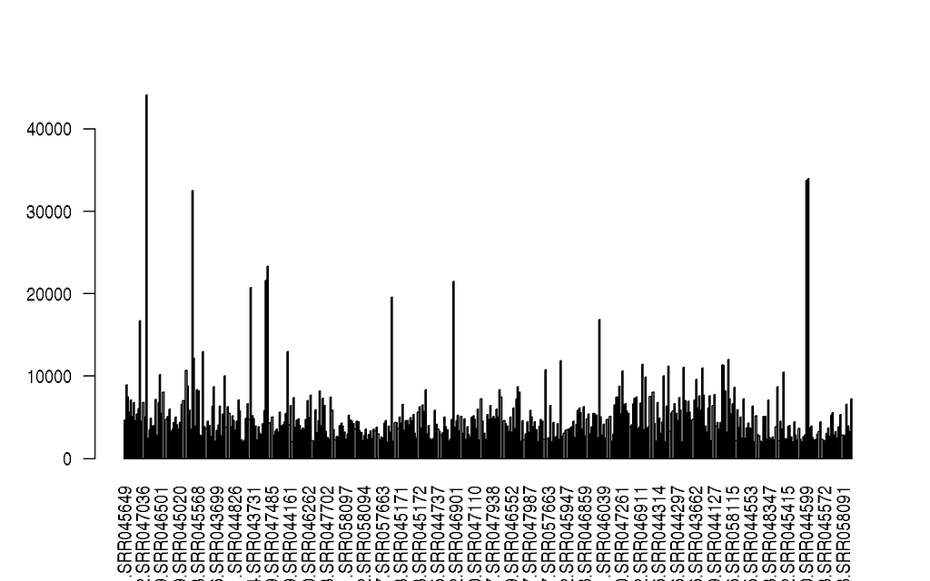

```r
# simple bar plot

barplot(sample_sums(ps0), las=2)
```

You can see there is uneven sequencing depth.

```r
summary(sample_sums(ps0))
```

```
##    Min. 1st Qu.  Median    Mean 3rd Qu.    Max.
##    2011    3142    4328    5184    5855   44106
```

From the above plot and summary, it is evident that there is a large difference in the sequencing depth. Let us check for our important variable

```r
p_seqdepth <- plot_read_distribution(ps0, "scientific_name", "density")
```

```
## [1] "Done plotting"
```

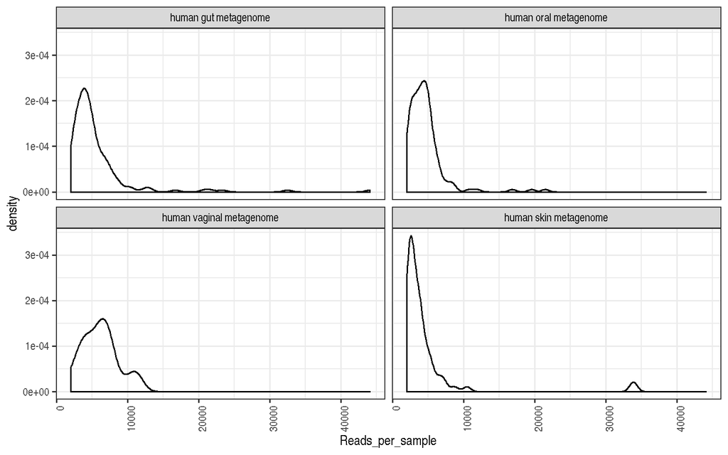

```r
print(p_seqdepth)
```

```r
ggsave("./figures/read_distribution.pdf", height = 4, width = 6)
```

What do you see from this plot?

## Distribution of OTUs

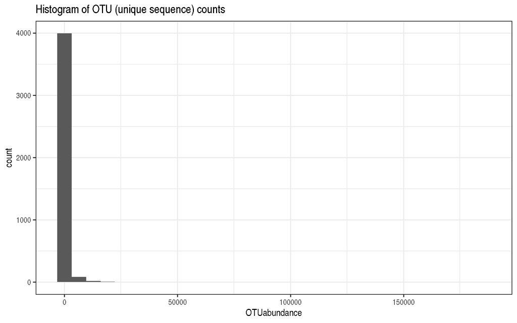

```r
# We make a data table with information on the OTUs
ps0_df_taxa =data.table(tax_table(ps0),OTUabundance = taxa_sums(ps0),OTU = taxa_names(ps0))
ps1_tax_plot <- ggplot(ps0_df_taxa, aes(OTUabundance)) + geom_histogram() + ggtitle("Histogram of OTU (unique sequence) counts") + theme_bw()
print(ps1_tax_plot)
```

Check how different phyla are represented in the total data.

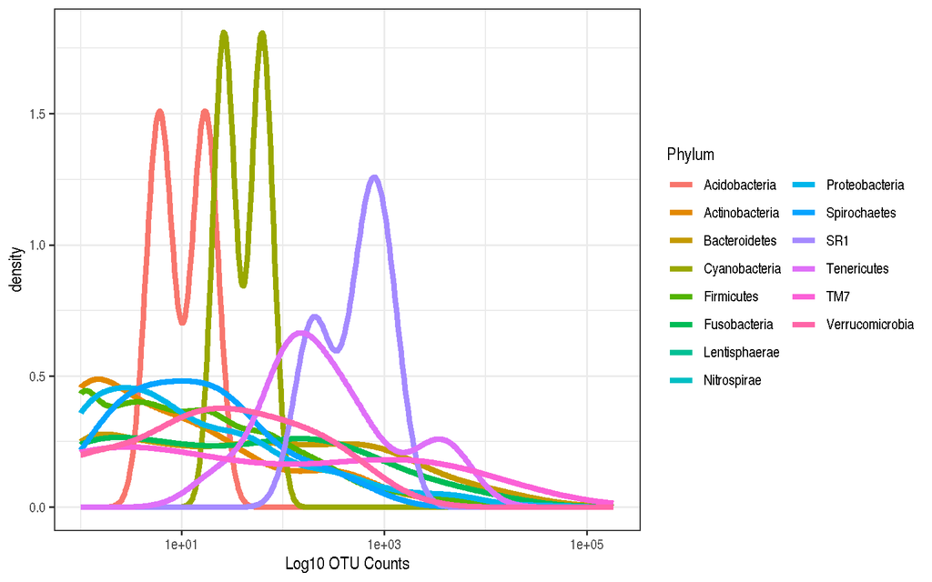

```r
taxasums = rowSums(otu_table(ps0))

taxatable <- as.data.frame.matrix(tax_table(ps0))


tax_plot1 <- ggplot(taxatable, aes(x = taxasums, color = taxatable[, "Phylum"]))
tax_plot1 <- tax_plot1 + geom_line(size = 1.5, stat = "density")
tax_plot1 <- tax_plot1 + theme_bw()
tax_plot1 <- tax_plot1 + guides(color=guide_legend(title="Phylum", nrow = 8))
tax_plot1 + scale_x_log10() + xlab("Log10 OTU Counts")
```

```r
ggsave("./figures/Distribution of OTUs.pdf", height = 4, width = 6)
```

Another way to identify dominant and rare outs in the dataset is as follows:

[figure not shown]

```r
p <- plot_taxa_prevalence(ps0, "Phylum")
p
```

[figure not shown]

```r
ggsave("./figures/OTU prevalence.pdf", height = 4, width = 6)


# Set reference to check OTUs present in less than 10%

p <- p + geom_hline(yintercept = 0.1, color = "steelblue")
p
```

[figure not shown]

```r
# Set reference to check OTUs present in less than 5%

p <- p + geom_hline(yintercept = 0.05, color = "red")
p
```

We can extract the prevalence and abundance data used for previous plot.

```r
prev_df <- p$data

head(prev_df)
```

```
##          abundance  prevalence Phylum
## 4213913 -0.8729403 0.048523207    SR1
## 4330849  0.7324490 0.124472574    SR1
## 4400869  0.3080430 0.092827004    SR1
## 4440970 -0.8579024 0.075949367    TM7
## 4299136 -6.1612073 0.002109705    TM7
## 3103396 -3.7633120 0.008438819    TM7
```

Use this data for some checks.

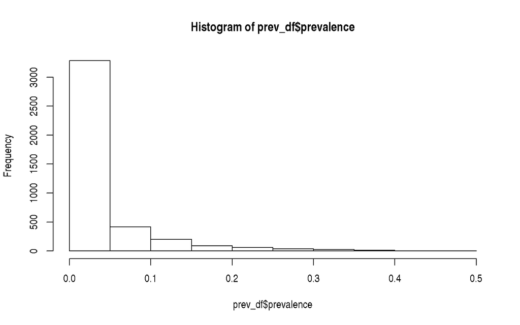

```r
# check for distribution of prevalence values

hist(prev_df$prevalence)
```

```r
# What can you see from the histogram?

# Check total OTUs
nrow(prev_df)
```

```
## [1] 4125
```

```r
# Check how many are present in  less than 5% samples
nrow(prev_df[prev_df$prevalence > 0.05, ])
```

```
## [1] 843
```

```r
# now check if you put this as a threshold for filtering how many OTUs will you loose?

nrow(prev_df[prev_df$prevalence > 0.05, ])/nrow(prev_df) *100
```

```
## [1] 20.43636
```

One of the common artifacts in sequencing data and taxonomy assignments is the classification of mitochondria and chloroplast.

```r
datatable(tax_table(ps0))
```

|  | Kingdom | Phylum | Class | Order | Family | Genus | Species |
| --- | --- | --- | --- | --- | --- | --- | --- |
| 4213913 | Bacteria | SR1 |  |  |  |  |  |
| 4330849 | Bacteria | SR1 |  |  |  |  |  |
| 4400869 | Bacteria | SR1 |  |  |  |  |  |
| 4440970 | Bacteria | TM7 | TM7-3 | CW040 | F16 |  |  |
| 4299136 | Bacteria | TM7 | TM7-3 | CW040 | F16 |  |  |
| 3103396 | Bacteria | TM7 | TM7-3 | CW040 |  |  |  |
| 4323100 | Bacteria | TM7 | TM7-3 | CW040 |  |  |  |
| 4365684 | Bacteria | TM7 | TM7-3 | CW040 |  |  |  |
| 584516 | Bacteria | TM7 | TM7-3 |  |  |  |  |
| 4339528 | Bacteria | TM7 | TM7-3 |  |  |  |  |

[output cut: 4115 more lines]

```r
# Family mitochondria
```

Remove the mitochondria OTUs.

```r
ps1 <- subset_taxa(ps0, Family != "mitochondria")

print(ps1)
```

```
## phyloseq-class experiment-level object
## otu_table()   OTU Table:         [ 3690 taxa and 474 samples ]
## sample_data() Sample Data:       [ 474 samples by 31 sample variables ]
## tax_table()   Taxonomy Table:    [ 3690 taxa by 7 taxonomic ranks ]
## phy_tree()    Phylogenetic Tree: [ 3690 tips and 3689 internal nodes ]
```

```r
# also check how many lost

ntaxa(ps0)-ntaxa(ps1)
```

```
## [1] 435
```

```r
# Save this filtered phyloseq object for later analysis

saveRDS(ps1 , "./phyobjects/ps1.rds")
```

Check how many total reads are there in the data set.

```r
#total number of reads in the dataset
reads_per_OTU <- taxa_sums(ps1)
print(sum(reads_per_OTU))
```

```
## [1] 2398446
```

There are 2398446 reads in the total data set.  
How many OTUs are less than 10 reads and how many reads do they contain?

```r
print(length(reads_per_OTU[reads_per_OTU < 10]))
```

```
## [1] 1678
```

```r
print(sum(reads_per_OTU[reads_per_OTU < 10]))
```

```
## [1] 5198
```

To put this into context; out of the 3690 OTUs, a 1678 OTUs contain less than 10 reads, which is:

```r
print((1678/3690)*100)
```

```
## [1] 45.47425
```

This is a major drawback of the OTU picking strategy. This percent can be lowered with NG_tax, DADA2, Deblur like approaches.

Let us see how many singletons are there?

```r
length(which(taxa_sums(ps1) <= 1))
```

```
## [1] 613
```

Let us see how many doubletons are there?

```r
length(which(taxa_sums(ps1) == 2))
```

```
## [1] 279
```

Let us see how many Singletons and doubletons are there?

```r
length(which(taxa_sums(ps1) <= 2))
```

```
## [1] 892
```

Singletons and doubletons

```r
round((892/3690)*100, digits = 2)
```

```
## [1] 24.17
```

24.17% of the OTUs are doubletons or singletons. This is suggests that there can be potentially spurious OTUs.

# Alpha diversities

Alpha diversity measures are used to identify within individual taxa richness and eveness. The commonly used metrices/indices are Shannon, Inverse Simpson, Simpson, Gini, Observed and Chao1. These indices do not take into account the phylogeny of the taxa identified in sequencing. Phylogenetic diversity (Faith’s PD) uses phylogenetic distance to calculate the diversity of a given sample.

*It is important to note that, alpha diversity indices are sensitive to noise that is inherent to application of polymerase chain reaction and the sequencing errors.*

One has to consider the sequecing depth (how much you have sampled) for each sample. If there is a large difference, then it is important to normalize the samples to equal sampling depth. First we look at the sampling depth (no. of reads per sample)

# Load packages

```r
library(microbiome) # data analysis and visualisation
library(phyloseq) # also the basis of data object. Data analysis and visualisation
library(microbiomeutilities) # some utility tools
library(RColorBrewer) # nice color options
library(ggpubr) # publication quality figures, based on ggplot2
library(DT) # interactive tables in html and markdown
library(data.table) # alternative to data.frame
library(dplyr) # data handling
```

The data for tutorial is stored as *.rds file in the R project folder.

We will use the filtered phyloseq object from previous tutorial.

```r
ps1 <- readRDS("./phyobjects/ps1.rds")


# use print option to see the data saved as phyloseq object.

print(ps1)
```

```
## phyloseq-class experiment-level object
## otu_table()   OTU Table:         [ 3690 taxa and 474 samples ]
## sample_data() Sample Data:       [ 474 samples by 31 sample variables ]
## tax_table()   Taxonomy Table:    [ 3690 taxa by 7 taxonomic ranks ]
## phy_tree()    Phylogenetic Tree: [ 3690 tips and 3689 internal nodes ]
```

```r
summary(sample_sums(ps1))
```

```
##    Min. 1st Qu.  Median    Mean 3rd Qu.    Max.
##    1286    3063    4192    5060    5790   41694
```

As is evident there is a large difference in the numer of reads. Minimum is 1286 and maximum is 41694!! There is a ~30X difference!  
We will normalise to the lowest depth of atleast 2000 reads to keep maximum samples for our anlaysis. This can be varied to remove samples with lower sequencing depth. This descion will depend on the research question being addressed.

# Equal sample sums

```r
set.seed(9242)  # This will help in reprodcuing the filtering and nomalisation.

ps0.rar <- rarefy_even_depth(ps1, sample.size = 2000)
```

```
## You set `rngseed` to FALSE. Make sure you've set & recorded
##  the random seed of your session for reproducibility.
## See `?set.seed`
```

```
## ...
```

```
## 12 samples removedbecause they contained fewer reads than `sample.size`.
```

```
## Up to first five removed samples are:
```

```
## 1927.SRS020470.SRX022097.SRR0576631927.SRS049823.SRX020523.SRR0464141927.SRS020119.SRX020676.SRR0478441927.SRS020606.SRX022097.SRR0576631927.SRS011634.SRX020659.SRR047489
```

```
## ...
```

```
## 653OTUs were removed because they are no longer
## present in any sample after random subsampling
```

```
## ...
```

```r
saveRDS(ps0.rar, "./phyobjects/ps0.rar.rds")
```

Check how mauch data you have now

```r
ps0.rar <- readRDS("./phyobjects/ps0.rar.rds")


print(ps0.rar)
```

```
## phyloseq-class experiment-level object
## otu_table()   OTU Table:         [ 3037 taxa and 462 samples ]
## sample_data() Sample Data:       [ 462 samples by 31 sample variables ]
## tax_table()   Taxonomy Table:    [ 3037 taxa by 7 taxonomic ranks ]
## phy_tree()    Phylogenetic Tree: [ 3037 tips and 3036 internal nodes ]
```

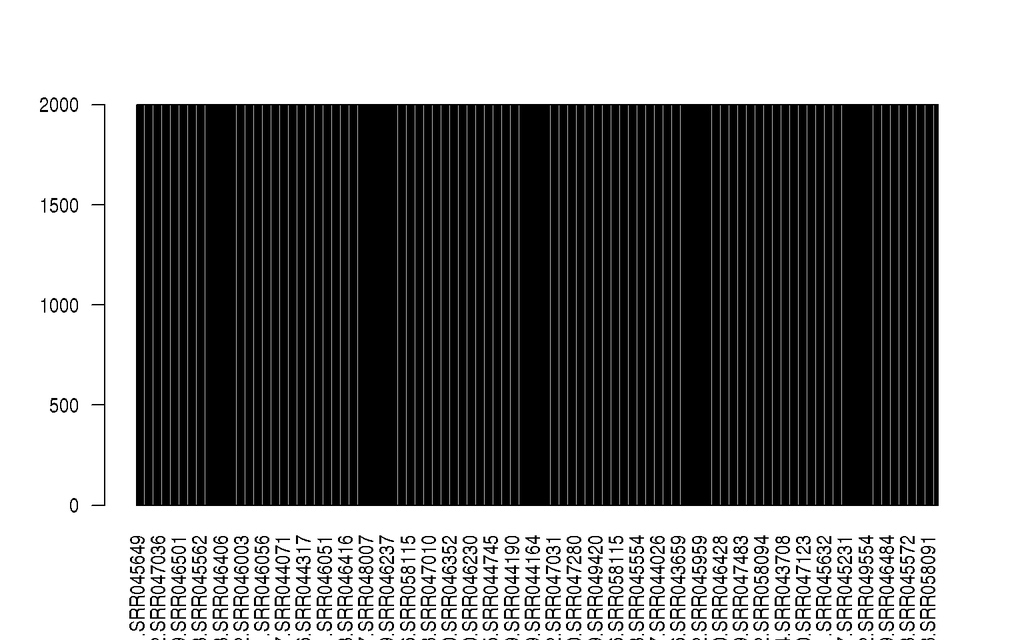

```r
 # quick check for sampling depth

barplot(sample_sums(ps0.rar), las =2)
```

[figure not shown]

```r
# quick check taxa prevalence

p.rar <- plot_taxa_prevalence(ps0.rar, "Phylum")

p.rar
```

Compare this to taxa prevalence plot from part I of the tutorial.

Do you see any difference?

# Diversities

## Non-phylogenetic diversities

For more diversity indices please refer to [Microbiome Package](http://microbiome.github.io/microbiome/Diversity.html)

Let use calcualte diversity

```r
hmp.div <- diversities(ps0.rar, index = "all")
```

```
## Observed richness
```

```
## Other forms of richness
```

```
## Diversity
```

```
## Evenness
```

```
## Dominance
```

```
## Rarity
```

```r
datatable(hmp.div)
```

|  | observed | chao1 | diversity_inverse_simpson | diversity_gini_simpson | diversity_shannon | diversity_fisher | diversity_coverage | evenness_camargo | evenness_pielou | evenness_simpson | evenness_evar | evenness_bulla | dominance_dbp | dominance_dmn | dominance_absolute | dominance_relative | dominance_simpson | dominance_core_abundance | dominance_gini | rarity_log_modulo_skewness | rarity_low_abundance | rarity_rare_abundance |
| --- | --- | --- | --- | --- | --- | --- | --- | --- | --- | --- | --- | --- | --- | --- | --- | --- | --- | --- | --- | --- | --- | --- |
| 1927.SRS014659.SRX020511.SRR045649 | 288 | 421.884615384615 | 41.9656720802384 | 0.976171 | 4.52563993192824 | 92.2695185812195 | 15 | 0.974329861111111 | 0.799165021158614 | 0.145714139167494 | 0.417045331198181 | 0.436850174216028 | 0.08 | 0.137 | 160 | 0.08 | 0.023829 |  | 0.972145538360223 | 2.06041118797793 | 0.153 | 0.918 |
| 1927.SRS015854.SRX020554.SRR043727 | 223 | 368.728571428571 | 17.2735438402543 | 0.942108 | 3.90143174063188 | 64.2776613092184 | 9 | 0.920349775784753 | 0.721529092385087 | 0.0774598378486738 | 0.369886834634323 | 0.362545045045045 | 0.19 | 0.2925 | 380 | 0.19 | 0.057892 |  | 0.983011524530788 | 2.0594686195079 | 0.1125 | 0.5665 |
| 1927.SRS015599.SRX020539.SRR044148 | 198 | 262.058823529412 | 24.056098822454 | 0.9584305 | 4.06412181883961 | 54.5706096739322 | 11 | 0.999010101010101 | 0.76851675515823 | 0.121495448598252 | 0.356675476792098 | 0.413756345177665 | 0.1525 | 0.2205 | 305 | 0.1525 | 0.0415695 |  | 0.982574580177804 | 2.05891893704434 | 0.0955 | 0.7085 |
| 1927.SRS015452.SRX020545.SRR044740 | 223 | 309.170212765957 | 17.9091112603537 | 0.9441625 | 3.84115162808454 | 64.2776613092184 | 7 | 0.995520179372197 | 0.710380914539968 | 0.0803099159657117 | 0.391818553450403 | 0.359578828828829 | 0.161 | 0.259 | 322 | 0.161 | 0.0558375 |  | 0.983403029305236 | 2.06071909418516 | 0.128 | 0.576 |
| 1927.SRS014442.SRX020511.SRR045656 | 179 | 256.066666666667 | 4.67143464429361 | 0.785933 | 2.99808739211363 | 47.5814269943055 | 2 | 0.980608938547486 | 0.577957280281317 | 0.0260974002474503 | 0.403991202899181 | 0.327474719101124 | 0.452 | 0.521 | 904 | 0.452 | 0.214067 |  | 0.988707606190321 | 2.06094500437428 | 0.091 | 0.339 |
| 1927.SRS014287.SRX020511.SRR045664 | 215 | 315.347222222222 | 14.1420712477549 | 0.929289 | 3.88903785840569 | 61.10811395031 | 10 | 1 | 0.724129579770153 | 0.0657770755709532 | 0.373113425686522 | 0.379509345794393 | 0.24 | 0.292 | 480 | 0.24 | 0.070711 |  | 0.98266315442871 | 2.06078572348591 | 0.104 | 0.5465 |
| 1927.SRS049428.SRX020670.SRR047663 | 185 | 251.014705882353 | 21.0265144347022 | 0.952441 | 3.77838354846677 | 49.7523685629077 | 7 | 0.910983783783784 | 0.72377892907522 | 0.113656834782174 | 0.352657500914428 | 0.352038043478261 | 0.114 | 0.2035 | 228 | 0.114 | 0.047559 |  | 0.986313467237405 | 2.05994422001026 | 0.0915 | 0.566 |
| 1927.SRS019910.SRX020516.SRR044347 | 176 | 246.620689655172 | 14.7638521843119 | 0.932267 | 3.60245564223644 | 46.5084859332956 | 6 | 0.879011363636364 | 0.696734705241045 | 0.0838855237744996 | 0.3531208670625 | 0.346514285714286 | 0.189 | 0.29 | 378 | 0.189 | 0.067733 |  | 0.987570299637802 | 2.05949034450245 | 0.0865 | 0.554 |
| 1927.SRS050422.SRX020511.SRR045628 | 271 | 366.043103448276 | 17.3148180212626 | 0.942246 | 4.0728125001972 | 84.5589921421017 | 7 | 0.955715867158672 | 0.727012873239565 | 0.0638923174216332 | 0.447440273357299 | 0.400268518518519 | 0.1875 | 0.2925 | 375 | 0.1875 | 0.057754 |  | 0.976700691471848 | 2.06106632215503 | 0.1525 | 0.529 |
| 1927.SRS064276.SRX020670.SRR046347 | 186 | 266 | 13.1889582041915 | 0.924179 | 3.5020951697755 | 50.11744446769 | 5 | 1 | 0.67016167993598 | 0.0709083774418895 | 0.35548194473301 | 0.329183783783784 | 0.184 | 0.3255 | 368 | 0.184 | 0.075821 |  | 0.988007902535394 | 2.06048389150223 | 0.0995 | 0.589 |

[output cut: 452 more lines]

This is one way to plot your data.

```r
# get the metadata out as seprate object
hmp.meta <- meta(ps0.rar)


# Add the rownames as a new colum for easy integration later.
hmp.meta$sam_name <- rownames(hmp.meta)

# Add the rownames to diversity table
hmp.div$sam_name <- rownames(hmp.div)

# merge these two data frames into one
div.df <- merge(hmp.div,hmp.meta, by = "sam_name")

# check the tables
colnames(div.df)
```

```
##  [1] "sam_name"                    "observed"
##  [3] "chao1"                       "diversity_inverse_simpson"
##  [5] "diversity_gini_simpson"      "diversity_shannon"
##  [7] "diversity_fisher"            "diversity_coverage"
##  [9] "evenness_camargo"            "evenness_pielou"
## [11] "evenness_simpson"            "evenness_evar"
## [13] "evenness_bulla"              "dominance_dbp"
## [15] "dominance_dmn"               "dominance_absolute"
## [17] "dominance_relative"          "dominance_simpson"
## [19] "dominance_core_abundance"    "dominance_gini"
## [21] "rarity_log_modulo_skewness"  "rarity_low_abundance"
## [23] "rarity_rare_abundance"       "X.SampleID"
## [25] "BarcodeSequence"             "LinkerPrimerSequence"
## [27] "run_prefix"                  "body_habitat"
## [29] "body_product"                "body_site"
## [31] "bodysite"                    "dna_extracted"
## [33] "elevation"                   "env"
## [35] "env_biome"                   "env_feature"
## [37] "env_material"                "env_package"
## [39] "geo_loc_name"                "host_common_name"
## [41] "host_scientific_name"        "host_subject_id"
## [43] "host_taxid"                  "latitude"
## [45] "longitude"                   "physical_specimen_location"
## [47] "physical_specimen_remaining" "psn"
## [49] "public"                      "sample_type"
## [51] "scientific_name"             "sequencecenter"
## [53] "title"                       "Description"
```

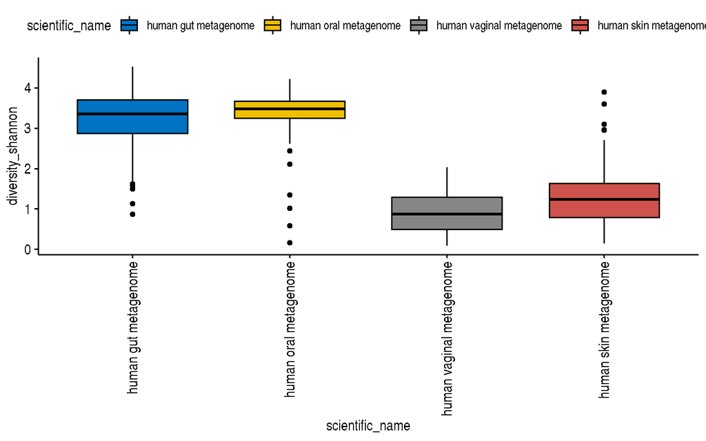

```r
# Now use this data frame to plot
p <- ggboxplot(div.df, x = "scientific_name", y = "diversity_shannon",
              fill = "scientific_name", palette = "jco")
p + rotate_x_text()
```

```r
colnames(hmp.div)
```

```
##  [1] "observed"                   "chao1"
##  [3] "diversity_inverse_simpson"  "diversity_gini_simpson"
##  [5] "diversity_shannon"          "diversity_fisher"
##  [7] "diversity_coverage"         "evenness_camargo"
##  [9] "evenness_pielou"            "evenness_simpson"
## [11] "evenness_evar"              "evenness_bulla"
## [13] "dominance_dbp"              "dominance_dmn"
## [15] "dominance_absolute"         "dominance_relative"
## [17] "dominance_simpson"          "dominance_core_abundance"
## [19] "dominance_gini"             "rarity_log_modulo_skewness"
## [21] "rarity_low_abundance"       "rarity_rare_abundance"
## [23] "sam_name"
```

Alternative way

```r
# convert phyloseq object into a long data format.

div.df2 <- div.df[,c("scientific_name", "diversity_inverse_simpson", "diversity_gini_simpson", "diversity_shannon", "diversity_fisher", "diversity_coverage")]

# the names are not pretty. we can replace them

colnames(div.df2) <- c("Location", "Inverse Simpson", "Gini-Simpson", "Shannon", "Fisher", "Coverage")

# check
colnames(div.df2)
```

```
## [1] "Location"        "Inverse Simpson" "Gini-Simpson"    "Shannon"
## [5] "Fisher"          "Coverage"
```

```r
div_df_melt <- reshape2::melt(div.df2)
head(div_df_melt)
```

```
##                Location        variable    value
## 1  human gut metagenome Inverse Simpson 18.25584
## 2  human gut metagenome Inverse Simpson 18.11004
## 3 human oral metagenome Inverse Simpson 12.79460
## 4 human oral metagenome Inverse Simpson 12.07591
## 5  human gut metagenome Inverse Simpson 11.20881
## 6  human gut metagenome Inverse Simpson 11.51715
```

The diversity indices are stored under column named *variable*.

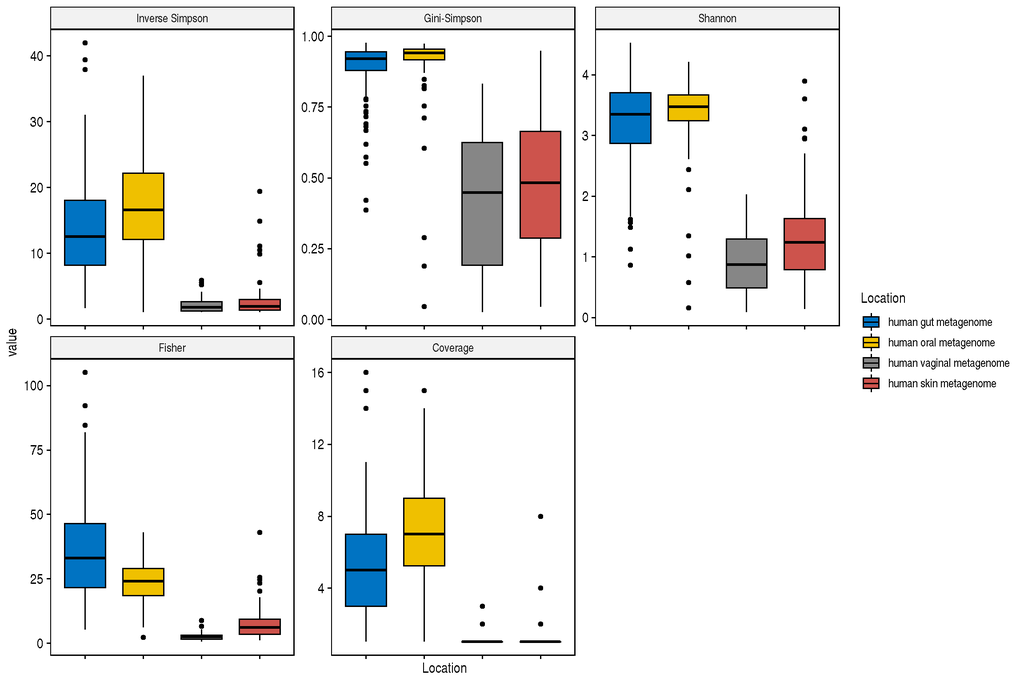

```r
# Now use this data frame to plot
p <- ggboxplot(div_df_melt, x = "Location", y = "value",
              fill = "Location",
              palette = "jco",
              legend= "right",
              facet.by = "variable",
              scales = "free")

p <- p + rotate_x_text()
# we will remove the x axis lables

p <- p + rremove("x.text")
p
```

```r
# ggsave("./figures/Diversities.pdf", height = 4, width = 10)
```

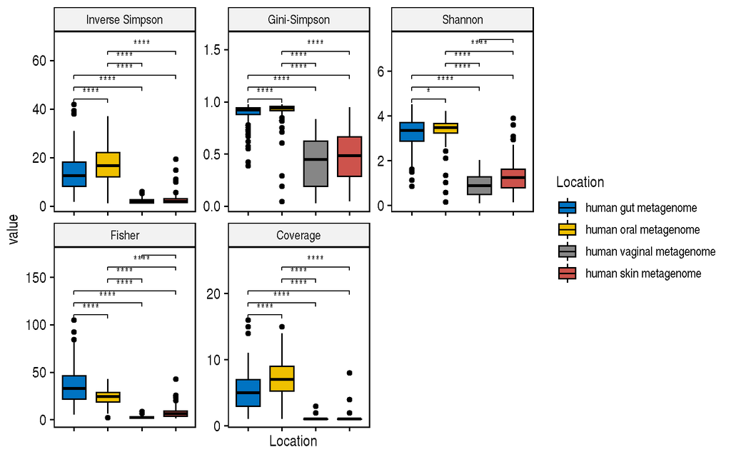

```r
lev <- levels(div_df_melt$Location) # get the variables

# make a pairwise list that we want to compare.
L.pairs <- combn(seq_along(lev), 2, simplify = FALSE, FUN = function(i)lev[i])

pval <- list(cutpoints = c(0, 0.0001, 0.001, 0.01, 0.05, 0.1, 1), symbols = c("****", "***", "**", "*", "n.s"))

p2 <- p + stat_compare_means(comparisons = L.pairs,
                             label = "p.signif",
                             symnum.args = list(cutpoints = c(0, 0.0001, 0.001, 0.01, 0.05, 0.1, 1),
                                                symbols = c("****", "***", "**", "*", "n.s")))

p2
```

## Phylogenetic diversity

Phylogenetic diversity is calculated using the `picante` package.

```r
library(picante)

ps0.rar.otutab <- as.data.frame(ps0.rar@otu_table)

ps0.rar.tree <- ps0.rar@phy_tree

# hmp.meta from previous code chunks

df.pd <- pd(t(ps0.rar.otutab), ps0.rar.tree,include.root=F) # t(ou_table) transposes the table for use in picante and the tre file comes from the first code chunck we used to read tree file (see making a phyloseq object section).


datatable(df.pd)
```

|  | PD | SR |
| --- | --- | --- |
| 1927.SRS014659.SRX020511.SRR045649 | 20.83803 | 288 |
| 1927.SRS015854.SRX020554.SRR043727 | 15.53026 | 223 |
| 1927.SRS015599.SRX020539.SRR044148 | 14.75744 | 198 |
| 1927.SRS015452.SRX020545.SRR044740 | 17.0483 | 223 |
| 1927.SRS014442.SRX020511.SRR045656 | 12.56475 | 179 |
| 1927.SRS014287.SRX020511.SRR045664 | 14.21279 | 215 |
| 1927.SRS049428.SRX020670.SRR047663 | 12.64104 | 185 |
| 1927.SRS019910.SRX020516.SRR044347 | 13.86345 | 176 |
| 1927.SRS050422.SRX020511.SRR045628 | 16.22075 | 271 |
| 1927.SRS064276.SRX020670.SRR046347 | 12.86249 | 186 |

[output cut: 452 more lines]

now we need to plot PD. Check above how to get the metadata file from phyloseq object.

```r
# now we need to plot PD

# We will add the results of PD to this file and then plot.

hmp.meta$Phylogenetic_Diversity <- df.pd$PD
```

**Plot**

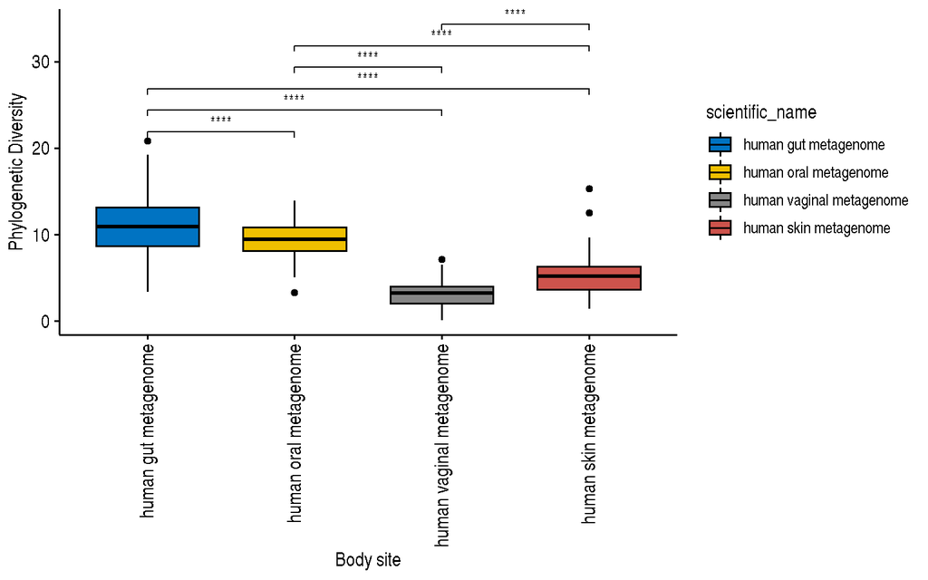

```r
pd.plot <- ggboxplot(hmp.meta, x = "scientific_name",
                     y = "Phylogenetic_Diversity",
                     fill = "scientific_name",
                     palette = "jco",
                     ylab = "Phylogenetic Diversity",
                     xlab = "Body site",
                     legend = "right")
pd.plot <- pd.plot + rotate_x_text()

pd.plot + stat_compare_means(comparisons = L.pairs,
                             label = "p.signif",
                             symnum.args = list(cutpoints = c(0, 0.0001, 0.001, 0.01, 0.05, 0.1, 1),
                                                symbols = c("****", "***", "**", "*", "n.s")))
```

# Composition plots

Barplots are an easy and intuitive way of visualising the composition of your samples. However, the way this is implented in phyloseq causes problems with the order of the taxa in the legend at higher taxonomic levels.

We will use the filtered phyloseq object from the Microbiome Analytics Workshop 2018 tutorial I.

# Load packages

```r
library(microbiome) # data analysis and visualisation
library(phyloseq) # also the basis of data object. Data analysis and visualisation
library(RColorBrewer) # nice color options
library(ggpubr) # publication quality figures, based on ggplot2
library(dplyr) # data handling
```

```r
ps1 <- readRDS("./phyobjects/ps1.rds")

# use print option to see the data saved as phyloseq object.

print(ps1)
```

```
## phyloseq-class experiment-level object
## otu_table()   OTU Table:         [ 3690 taxa and 474 samples ]
## sample_data() Sample Data:       [ 474 samples by 31 sample variables ]
## tax_table()   Taxonomy Table:    [ 3690 taxa by 7 taxonomic ranks ]
## phy_tree()    Phylogenetic Tree: [ 3690 tips and 3689 internal nodes ]
```

# Barplot counts

```r
ps1.com <- ps1

# We need to set Palette
taxic <- as.data.frame(ps1.com@tax_table)  # this will help in setting large color options

#colourCount = length(unique(taxic$Family))  #define number of variable colors based on number of Family (change the level accordingly to phylum/class/order)
#getPalette = colorRampPalette(brewer.pal(12, "Paired"))  # change the palette as well as the number of colors will change according to palette.

taxic$OTU <- rownames(taxic)  # Add the OTU ids from OTU table into the taxa table at the end.
colnames(taxic)  # You can see that we now have extra taxonomy levels.
```

```
## [1] "Kingdom" "Phylum"  "Class"   "Order"   "Family"  "Genus"   "Species"
## [8] "OTU"
```

[figure not shown]

```r
taxmat <- as.matrix(taxic)  # convert it into a matrix.
new.tax <- tax_table(taxmat)  # convert into phyloseq compatible file.
tax_table(ps1.com) <- new.tax  # incroporate into phyloseq Object



# now edit the unclassified taxa
# tax_table(ps1.com)[tax_table(ps1.com)[, "Family"] == "f__", "Family"] <- "Unclassified family"


# We will also remove the 'f__' patterns for cleaner labels
# tax_table(ps1.com)[, colnames(tax_table(ps1.com))] <- gsub(tax_table(ps1.com)[,
#    colnames(tax_table(ps1.com))], pattern = "[a-z]__", replacement = "")

# it would be nice to have the Taxonomic names in italics.
# for that we set this

guide_italics <- guides(fill = guide_legend(label.theme = element_text(size = 15,
    face = "italic", colour = "Black", angle = 0)))


## Now we need to plot at family level, We can do it as follows:

# first remove the phy_tree

ps1.com@phy_tree <- NULL

# Second merge at family level

ps1.com.fam <- aggregate_taxa(ps1.com, "Family")

plot.composition.COuntAbun <- plot_composition(ps1.com.fam) + theme(legend.position = "bottom") +
    scale_fill_brewer("Family", palette = "Paired") + theme_bw() +
    theme(axis.text.x = element_text(angle = 90)) +
    labs(title = "Relative abundance") +
    guide_italics +
    theme(legend.title = element_text(size=18))

plot.composition.COuntAbun
```

```r
#ggsave("./Test_Outputfiles/Family_barplot_CountAbundance.pdf", height = 6, width = 8)
```

This plot is based on the reads/sample. You can see the reads are not evenly distributed over the samples, nevertheless their overall composition seems to be the same. The only thing that is different is the scaling. You don’t need any other normalisation alogorithms. To check this in the next step we plot the relative abundance.

# Barplot relative abundance

Make it relative abundance

[figure not shown]

```r
# the previous pseq object ps1.com.fam is only counts.

# Use traqnsform function of microbiome to convert it to rel abun.

ps1.com.rel <- microbiome::transform(ps1.com, "compositional")

ps1.com.fam2 <- aggregate_taxa(ps1.com.rel, "Family")


plot.composition.relAbun <- plot_composition(ps1.com.fam2,
                                             sample.sort = "scientific_name",
                                             x.label = "env_material") + theme(legend.position = "bottom") + scale_fill_brewer("Family", palette = "Paired") + theme_bw() +
    theme(axis.text.x = element_text(angle = 90)) +
    labs(title = "Relative abundance") +
    guide_italics +
    theme(legend.title = element_text(size=18))

plot.composition.relAbun
```

```r
#ggsave("./figures/Family_barplot_RelAbundance.pdf", height = 6, width = 8)
```

# Barplot customize

```r
data.com <- plot.composition.relAbun$data
colnames(data.com)
```

```
## [1] "Tax"       "Sample"    "Abundance" "xlabel"
```

```r
p.com <- ggplot(data.com, aes(x = Sample, y = Abundance, fill = Tax))
p.com <- p.com + geom_bar(position = "stack", stat = "identity")
p.com <- p.com + scale_x_discrete(labels = data.com$xlabel, breaks = data.com$Sample)
p.com <- p.com + facet_grid(~xlabel, scales = "free") + theme_bw()
p.com <- p.com + scale_fill_brewer("Family", palette = "Paired")
p.com <- p.com + rremove("x.text")

ggsave("./figures/Composition plots.pdf", height = 4, width = 6)
```

for more information [Microbiome tutorial](http://microbiome.github.io/microbiome/Composition.html)

# Heatmaps

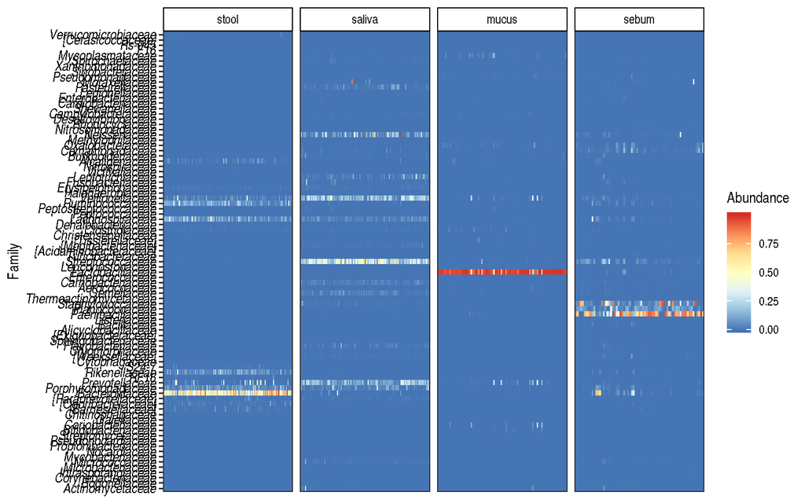

```r
# base plot
p.heat <- ggplot(data.com, aes(x = Sample, y = Tax)) +
            geom_tile(aes(fill = Abundance))

# Change color
p.heat <- p.heat + scale_fill_distiller("Abundance", palette = "RdYlBu") +
            theme_bw()

# Make bacterial names italics
p.heat <- p.heat + theme(axis.text.y = element_text(colour = 'black',
                                                    size = 10,
                                                    face = 'italic'))
# Make seperate samples based on main varaible
p.heat <- p.heat + facet_grid(~xlabel,
                              scales = "free") + rremove("x.text")

p.heat <- p.heat + ylab("Family")

#Clean the x-axis
p.heat <- p.heat + theme(axis.title.x=element_blank(),
                     axis.text.x=element_blank(),
                     axis.ticks.x=element_blank())

# Clean the facet label box
p.heat <- p.heat + theme(legend.key = element_blank(),
                     strip.background = element_rect(colour="black", fill="white"))

print(p.heat)
```

```r
ggsave("./figures/Heatmap.pdf", height = 4, width = 6)


# + geom_text(aes(label = round(Abundance)), size = 0.4)
```

# Extra

```r
ps_df <- microbiomeutilities::phy_to_ldf(ps1.com, transform.counts = "compositional")
```

```
## An additonal column Sam_rep with sample names is created for reference purpose
```

```r
colnames(ps_df)
```

```
##  [1] "OTUID"                       "Kingdom"
##  [3] "Phylum"                      "Class"
##  [5] "Order"                       "Family"
##  [7] "Genus"                       "Species"
##  [9] "OTU"                         "Sam_rep"
## [11] "Abundance"                   "X.SampleID"
## [13] "BarcodeSequence"             "LinkerPrimerSequence"
## [15] "run_prefix"                  "body_habitat"
## [17] "body_product"                "body_site"
## [19] "bodysite"                    "dna_extracted"
## [21] "elevation"                   "env"
## [23] "env_biome"                   "env_feature"
## [25] "env_material"                "env_package"
## [27] "geo_loc_name"                "host_common_name"
## [29] "host_scientific_name"        "host_subject_id"
## [31] "host_taxid"                  "latitude"
## [33] "longitude"                   "physical_specimen_location"
## [35] "physical_specimen_remaining" "psn"
## [37] "public"                      "sample_type"
## [39] "scientific_name"             "sequencecenter"
## [41] "title"                       "Description"
```

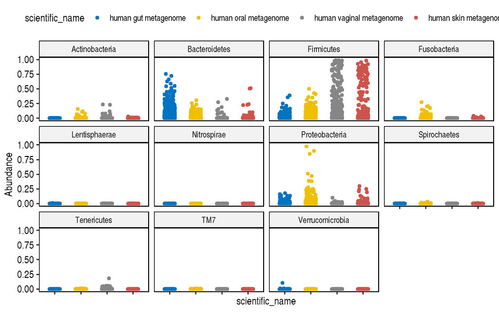

```r
# this data.frame can be used to customize several plots.

# example boxplot at phylum level

p.box <- ggstripchart(ps_df, "scientific_name", "Abundance",
                      facet.by = "Phylum", color = "scientific_name",
                      palette = "jco")

p.box + rremove("x.text")
```

# Load packages and data

```r
library(microbiome) # data analysis and visualisation
library(phyloseq) # also the basis of data object. Data analysis and visualisation
library(RColorBrewer) # nice color options
library(ggpubr) # publication quality figures, based on ggplot2
library(dplyr) # data handling
```

For more information:

[Waste Not, Want Not: Why Rarefying Microbiome Data Is Inadmissible](http://journals.plos.org/ploscompbiol/article?id=10.1371/journal.pcbi.1003531).

[Normalisation and data transformation](https://microbiomejournal.biomedcentral.com/articles/10.1186/s40168-017-0237-y).

[What is Constrained and Unconstrained Ordination](http://www.davidzeleny.net/anadat-r/doku.php/en:ordination).

```r
# read non rarefied data
ps1 <- readRDS("./phyobjects/ps1.rds")

# read non rarefied data
ps0.rar.rds <- readRDS("./phyobjects/ps0.rar.rds")
# use print option to see the data saved as phyloseq object.
```

# Phylogenetic beta-diversity metrics

## Unweighted Unifrac

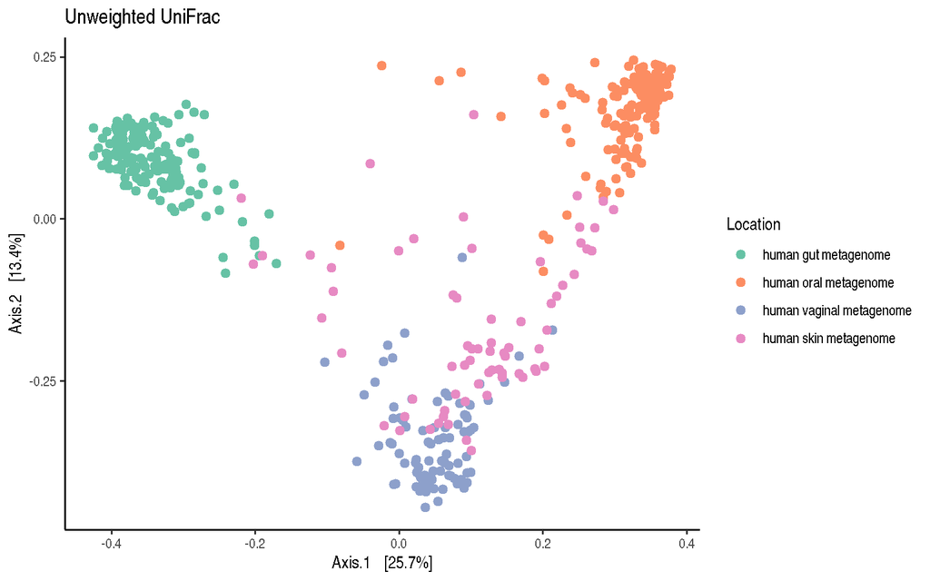

```r
ps1.rel <- transform(ps1, "compositional")

ordu.unwt.uni <- ordinate(ps1.rel , "PCoA", "unifrac", weighted=F)

# check for Eigen values
# barplot(ordu.unwt.uni$values$Eigenvalues[1:10])

unwt.unifrac <- plot_ordination(ps1.rel,
                                     ordu.unwt.uni, color="scientific_name")
unwt.unifrac <- unwt.unifrac + ggtitle("Unweighted UniFrac") + geom_point(size = 2)
unwt.unifrac <- unwt.unifrac + theme_classic() + scale_color_brewer("Location", palette = "Set2")
print(unwt.unifrac)
```

## Weighted Unifrac

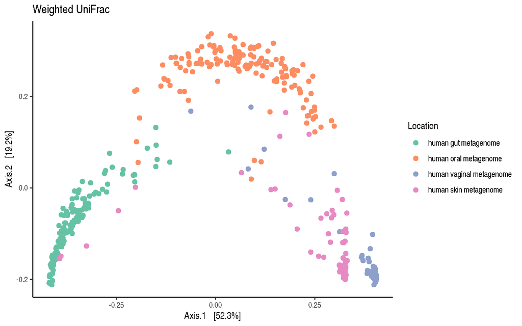

```r
ordu.wt.uni <- ordinate(ps1.rel , "PCoA", "unifrac", weighted=T)

# check for Eigen values
# barplot(ordu.unwt.uni$values$Eigenvalues[1:10])

wt.unifrac <- plot_ordination(ps1.rel,
                                     ordu.wt.uni, color="scientific_name")
wt.unifrac <- wt.unifrac + ggtitle("Weighted UniFrac") + geom_point(size = 2)
wt.unifrac <- wt.unifrac + theme_classic() + scale_color_brewer("Location", palette = "Set2")
print(wt.unifrac)
```

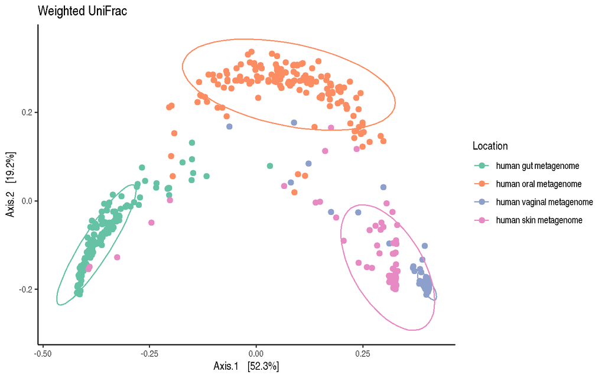

```r
print(wt.unifrac + stat_ellipse())
```

The figure brings forward an important characteristics of microbiome data call the ‘Horse-shoe effect’. An investigation and explaination for this can be found in the article by Morton JT., et al. 2017 [Uncovering the Horseshoe Effect in Microbial Analyses](http://msystems.asm.org/content/2/1/e00166-16).

## Population-level Density landscapes

[output not shown]

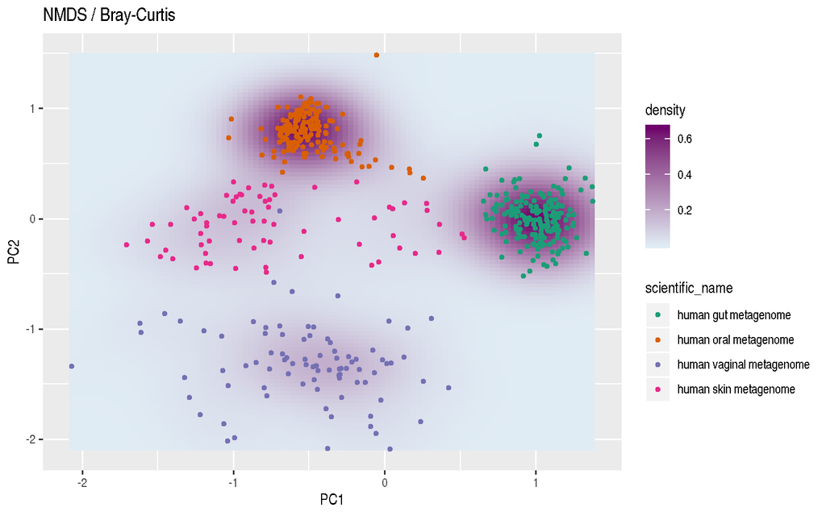

```r
p <- microbiome::plot_landscape(ps1.rel, "NMDS", "bray", col = "scientific_name") +
       labs(title = paste("NMDS / Bray-Curtis"))

p + scale_color_brewer(palette = "Dark2")+ scale_fill_gradient(low = "#e0ecf4", high = "#6e016b")
```

## PERMANOVA

```r
library(vegan)
metadf <- data.frame(sample_data(ps1.rel))

unifrac.dist <- UniFrac(ps1.rel,
                        weighted = TRUE,
                        normalized = TRUE,
                        parallel = FALSE,
                        fast = TRUE)

permanova <- adonis(unifrac.dist ~ scientific_name, data = metadf)

permanova
```

```
##
## Call:
## adonis(formula = unifrac.dist ~ scientific_name, data = metadf)
##
## Permutation: free
## Number of permutations: 999
##
## Terms added sequentially (first to last)
##
##                  Df SumsOfSqs MeanSqs F.Model      R2 Pr(>F)
## scientific_name   3    61.496 20.4985  410.98 0.72401  0.001 ***
## Residuals       470    23.442  0.0499         0.27599
## Total           473    84.938                 1.00000
## ---
## Signif. codes:  0 '***' 0.001 '**' 0.01 '*' 0.05 '.' 0.1 ' ' 1
```

## Checking the homogeneity condition

```r
ps.disper <- betadisper(unifrac.dist, metadf$scientific_name)
permutest(ps.disper, pairwise = TRUE)
```

```
##
## Permutation test for homogeneity of multivariate dispersions
## Permutation: free
## Number of permutations: 999
##
## Response: Distances
##            Df Sum Sq  Mean Sq      F N.Perm Pr(>F)
## Groups      3 0.9125 0.304150 22.998    999  0.001 ***
## Residuals 470 6.2158 0.013225
## ---
## Signif. codes:  0 '***' 0.001 '**' 0.01 '*' 0.05 '.' 0.1 ' ' 1
##
## Pairwise comparisons:
## (Observed p-value below diagonal, permuted p-value above diagonal)
##                          human gut metagenome human oral metagenome
## human gut metagenome                                     1.0000e-03
## human oral metagenome              6.4361e-08
## human vaginal metagenome           2.0164e-07            3.0628e-16
## human skin metagenome              1.7519e-01            7.3652e-02
##                          human vaginal metagenome human skin metagenome
## human gut metagenome                   1.0000e-03                 0.208
## human oral metagenome                  1.0000e-03                 0.074
## human vaginal metagenome                                          0.001
## human skin metagenome                  1.8573e-04
```

# Core microbiota

```r
library(microbiome) # data analysis and visualisation
library(phyloseq) # also the basis of data object. Data analysis and visualisation
library(RColorBrewer) # nice color options
library(ggpubr) # publication quality figures, based on ggplot2
library(dplyr) # data handling
```

# Core microbiota anlaysis

For more information:

[The adult intestinal core microbiota is determined by analysis depth and health status](https://www.sciencedirect.com/science/article/pii/S1198743X14609629?via%3Dihub).

[Intestinal microbiome landscaping: insight in community assemblage and implications for microbial modulation strategies](https://academic.oup.com/femsre/article/41/2/182/2979411).

[Intestinal Microbiota in Healthy Adults: Temporal Analysis Reveals Individual and Common Core and Relation to Intestinal Symptoms](http://journals.plos.org/plosone/article?id=10.1371/journal.pone.0023035).

We will use the filtered phyloseq object from previous tutorial.We will use the filtered phyloseq object from the Microbiome Analytics Workshop 2018 tutorial I.

```r
# read non rarefied data
ps1 <- readRDS("./phyobjects/ps1.rds")

# use print option to see the data saved as phyloseq object.
```

Subset the data to keep only stool samples.

```r
ps1.stool <- subset_samples(ps1, bodysite == "Stool")

# convert to relative abundance
ps1.stool.rel <- microbiome::transform(ps1.stool, "compositional")
print(ps1.stool.rel)
```

```
## phyloseq-class experiment-level object
## otu_table()   OTU Table:         [ 3690 taxa and 169 samples ]
## sample_data() Sample Data:       [ 169 samples by 31 sample variables ]
## tax_table()   Taxonomy Table:    [ 3690 taxa by 7 taxonomic ranks ]
## phy_tree()    Phylogenetic Tree: [ 3690 tips and 3689 internal nodes ]
```

```r
ps1.stool.rel2 <- prune_taxa(taxa_sums(ps1.stool.rel) > 0, ps1.stool.rel)

print(ps1.stool.rel2)
```

```
## phyloseq-class experiment-level object
## otu_table()   OTU Table:         [ 2717 taxa and 169 samples ]
## sample_data() Sample Data:       [ 169 samples by 31 sample variables ]
## tax_table()   Taxonomy Table:    [ 2717 taxa by 7 taxonomic ranks ]
## phy_tree()    Phylogenetic Tree: [ 2717 tips and 2716 internal nodes ]
```

Check of the core OTUs

```r
core.taxa.standard <- core_members(ps1.stool.rel2, detection = 0.001, prevalence = 50/100)

print(core.taxa.standard)
```

```
##  [1] "191483"  "194909"  "197214"  "177343"  "184753"  "560336"  "192684"
##  [8] "535375"  "193233"  "772282"  "4325533" "850586"  "196219"  "180082"
## [15] "330458"  "173996"
```

There are 16 OTUs that are core based on the cut-offs for prevalence and detection we choose. However, we only see IDs, not very informative. We can get the classification of these as below.

```r
# Extract the taxonomy table

taxonomy <- as.data.frame(tax_table(ps1.stool.rel2))

# Subset this taxonomy table to include only core OTUs
core_taxa_id <- subset(taxonomy, rownames(taxonomy) %in% core.taxa.standard)

DT::datatable(core_taxa_id)
```

|  | Kingdom | Phylum | Class | Order | Family | Genus | Species |
| --- | --- | --- | --- | --- | --- | --- | --- |
| 191483 | Bacteria | Bacteroidetes | Bacteroidia | Bacteroidales | Bacteroidaceae | Bacteroides |  |
| 194909 | Bacteria | Bacteroidetes | Bacteroidia | Bacteroidales | Bacteroidaceae | Bacteroides |  |
| 197214 | Bacteria | Bacteroidetes | Bacteroidia | Bacteroidales | Bacteroidaceae | Bacteroides |  |
| 177343 | Bacteria | Bacteroidetes | Bacteroidia | Bacteroidales | Bacteroidaceae | Bacteroides |  |
| 184753 | Bacteria | Bacteroidetes | Bacteroidia | Bacteroidales | Bacteroidaceae | Bacteroides |  |
| 560336 | Bacteria | Bacteroidetes | Bacteroidia | Bacteroidales | Bacteroidaceae | Bacteroides |  |
| 192684 | Bacteria | Bacteroidetes | Bacteroidia | Bacteroidales | Bacteroidaceae | Bacteroides |  |
| 535375 | Bacteria | Bacteroidetes | Bacteroidia | Bacteroidales | Bacteroidaceae | Bacteroides | ovatus |
| 193233 | Bacteria | Bacteroidetes | Bacteroidia | Bacteroidales | Bacteroidaceae | Bacteroides |  |
| 772282 | Bacteria | Bacteroidetes | Bacteroidia | Bacteroidales | Rikenellaceae |  |  |

[output cut: 6 more lines]

# Core abundance and diversity

Total core abundance in each sample (sum of abundances of the core members):

```r
core.abundance <- sample_sums(core(ps1.stool.rel2, detection = 0.001, prevalence = 50/100))

DT::datatable(as.data.frame(core.abundance))
```

|  | core.abundance |
| --- | --- |
| 1927.SRS014659.SRX020511.SRR045649 | 0.0465431540894713 |
| 1927.SRS015854.SRX020554.SRR043727 | 0.401378326996198 |
| 1927.SRS015599.SRX020539.SRR044148 | 0.282029950083195 |
| 1927.SRS015452.SRX020545.SRR044740 | 0.392269280562234 |
| 1927.SRS014442.SRX020511.SRR045656 | 0.567991933160472 |
| 1927.SRS014287.SRX020511.SRR045664 | 0.4 |
| 1927.SRS049428.SRX020670.SRR047663 | 0.40018176310209 |
| 1927.SRS019910.SRX020516.SRR044347 | 0.249308118081181 |
| 1927.SRS050422.SRX020511.SRR045628 | 0.464148033924441 |
| 1927.SRS064276.SRX020670.SRR046347 | 0.36194221234399 |

[output cut: 159 more lines]

# Core visualization

## Core heatmaps

This visualization method has been used for instance in [Intestinal microbiome landscaping: insight in community assemblage and implications for microbial modulation strategies](https://academic.oup.com/femsre/article/41/2/182/2979411).

Note that you can order the taxa on the heatmap with the order.taxa argument.

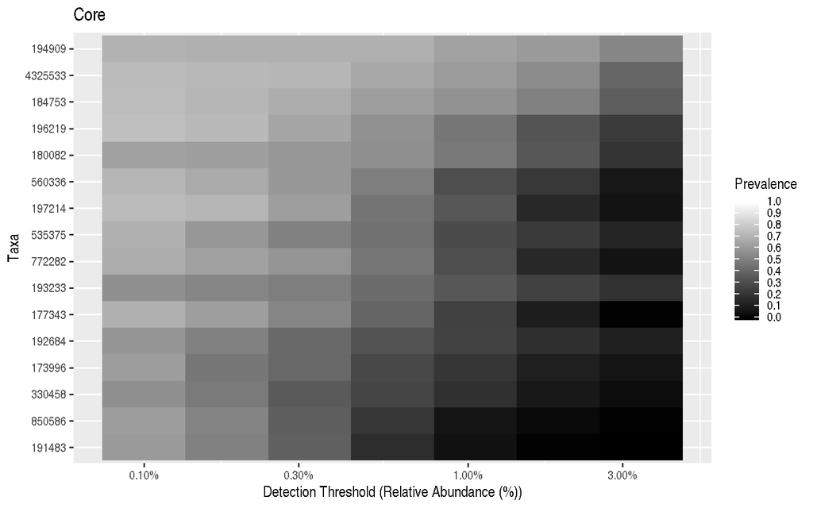

```r
# Core with compositionals:
prevalences <- seq(.05, 1, .05)
detections <- 10^seq(log10(1e-3), log10(.2), length = 10)

# Also define gray color palette
gray <- gray(seq(0,1,length=5))
p.core <- plot_core(ps1.stool.rel2, plot.type = "heatmap", colours = gray,
    prevalences = prevalences, detections = detections, min.prevalence = .5) +
    xlab("Detection Threshold (Relative Abundance (%))")
print(p.core)
```

```r
# Same with the viridis color palette
# color-blind friendly and uniform
# options: viridis, magma, plasma, inferno
# https://cran.r-project.org/web/packages/viridis/vignettes/intro-to-viridis.html
# Also discrete=TRUE versions available
library(viridis)
print(p.core + scale_fill_viridis())
```

[output not shown]

[figure not shown]

Color change

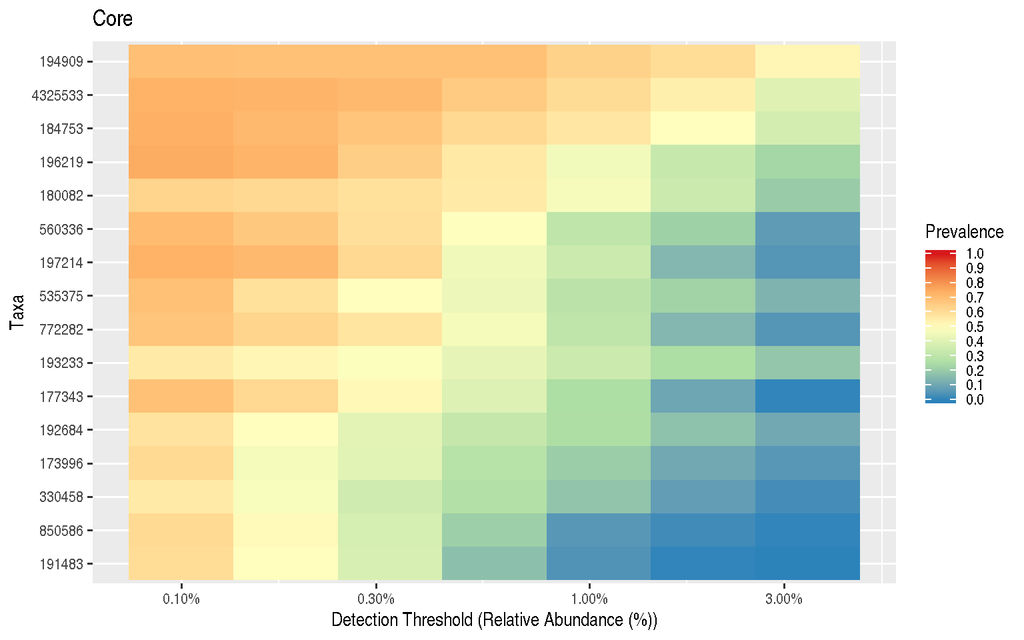

```r
# Core with compositionals:
prevalences <- seq(.05, 1, .05)
detections <- 10^seq(log10(1e-3), log10(.2), length = 10)

# Also define gray color palette
gray <- gray(seq(0,1,length=5))
p.core <- plot_core(ps1.stool.rel2,
                    plot.type = "heatmap",
                    colours = rev(brewer.pal(5, "Spectral")),
                    prevalences = prevalences,
                    detections = detections,
                    min.prevalence = .5) +
  xlab("Detection Threshold (Relative Abundance (%))")

print(p.core)
```

We have a custom script to format this figure which can be found in `scripts` folder in the `RProject`.

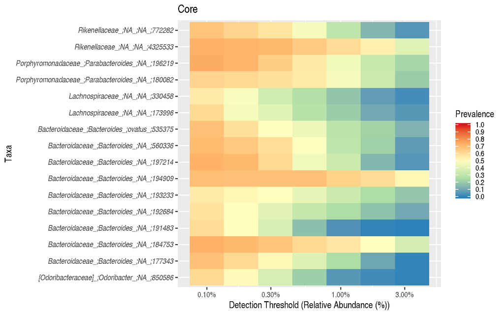

```r
source("./scripts/plot_core_assist.R")
plot_data <- p.core$data

df_plot <- plot_core_assist(plot_data, tax_table(ps1.stool.rel2), levels = "Family")

p.core$data <- df_plot

plot(p.core + theme(axis.text.y = element_text(face="italic")))
```

# Inference of Microbial Ecological Networks

More information on [SPIEC-EASI](http://journals.plos.org/ploscompbiol/article?id=10.1371/journal.pcbi.1004226).

This input for SPIEC-EASI is a counts table. The normalization and tranformation is done by the function. This is very handy tool.  
This step is heavy on computational memory and very slow. Noise filtered OTU-OTU level covariance would be ideal.

# Load packages and data

```r
library(devtools)
install_github("zdk123/SpiecEasi")

# Other packages you need to install are
install.packages("igraph")

install.packages("intergraph")
install.packages("GGally")
devtools::install_github("briatte/ggnet")

install.packages("network")
install.packages("ggnetwork")
```

```r
library(microbiome) # data analysis and visualisation
library(phyloseq) # also the basis of data object. Data analysis and visualisation
library(RColorBrewer) # nice color options
library(ggpubr) # publication quality figures, based on ggplot2
library(dplyr) # data handling
library(SpiecEasi) # Network analysis for sparse compositional data
library(network)
library(intergraph)
#devtools::install_github("briatte/ggnet")
library(ggnet)
library(igraph)
```

```r
ps1 <- readRDS("./phyobjects/ps1.rds")
```

**Select only stool samples**

We will subset our data to include only stool samples.

```r
ps1.stool <- subset_samples(ps1, bodysite == "Stool")
```

**For testing reduce the number of OTUs**

```r
ps1.stool.otu <- prune_taxa(taxa_sums(ps1.stool) > 100, ps1.stool)

# Add taxonomic classification to OTU ID
ps1.stool.otu.f <- microbiomeutilities::format_to_besthit(ps1.stool.otu)

head(tax_table(ps1.stool))
```

```
## Taxonomy Table:     [6 taxa by 7 taxonomic ranks]:
##         Kingdom    Phylum           Class
## 4440970 "Bacteria" "TM7"            "TM7-3"
## 4299136 "Bacteria" "TM7"            "TM7-3"
## 627481  "Bacteria" "TM7"            "TM7-3"
## 86812   "Bacteria" "Proteobacteria" "Epsilonproteobacteria"
## 4442127 "Bacteria" "Proteobacteria" "Epsilonproteobacteria"
## 4425150 "Bacteria" "Proteobacteria" "Epsilonproteobacteria"
##         Order               Family               Genus           Species
## 4440970 "CW040"             "F16"                NA              NA
## 4299136 "CW040"             "F16"                NA              NA
## 627481  "I025"              "Rs-045"             NA              NA
## 86812   "Campylobacterales" "Campylobacteraceae" "Campylobacter" NA
## 4442127 "Campylobacterales" "Campylobacteraceae" "Campylobacter" NA
## 4425150 "Campylobacterales" "Campylobacteraceae" "Campylobacter" NA
```

Check the difference in two phyloseq objects.

```r
head(tax_table(ps1.stool.otu.f))
```

[output not shown]

# Prepare data for SpiecEasi

The calcualtion of SpiecEasi are time consuming. For this tutorial we will have the necessary input files for SpiecEasi.

- OTU table
- Taxonomy table

We save it as *.rds* object.

```r
otu.c <- t(otu_table(ps1.stool.otu.f)@.Data) #extract the otu table from phyloseq object

tax.c <- as.data.frame(tax_table(ps1.stool.otu.f)@.Data)#extract the taxonomy information

head(tax.c)
```

```
##                          Domain         Phylum              Class
## OTU-359809:Sutterella  Bacteria Proteobacteria Betaproteobacteria
## OTU-215097:Sutterella  Bacteria Proteobacteria Betaproteobacteria
## OTU-179261:Sutterella  Bacteria Proteobacteria Betaproteobacteria
## OTU-41229:Sutterella   Bacteria Proteobacteria Betaproteobacteria
## OTU-4371362:Sutterella Bacteria Proteobacteria Betaproteobacteria
## OTU-178885:Sutterella  Bacteria Proteobacteria Betaproteobacteria
##                                  Order         Family      Genus
## OTU-359809:Sutterella  Burkholderiales Alcaligenaceae Sutterella
## OTU-215097:Sutterella  Burkholderiales Alcaligenaceae Sutterella
## OTU-179261:Sutterella  Burkholderiales Alcaligenaceae Sutterella
## OTU-41229:Sutterella   Burkholderiales Alcaligenaceae Sutterella
## OTU-4371362:Sutterella Burkholderiales Alcaligenaceae Sutterella
## OTU-178885:Sutterella  Burkholderiales Alcaligenaceae Sutterella
##                              Species               best_hit
## OTU-359809:Sutterella  g__Sutterella  OTU-359809:Sutterella
## OTU-215097:Sutterella  g__Sutterella  OTU-215097:Sutterella
## OTU-179261:Sutterella  g__Sutterella  OTU-179261:Sutterella
## OTU-41229:Sutterella   g__Sutterella   OTU-41229:Sutterella
## OTU-4371362:Sutterella g__Sutterella OTU-4371362:Sutterella
## OTU-178885:Sutterella  g__Sutterella  OTU-178885:Sutterella
```

```r
saveRDS(otu.c, "input_data/stool.otu.c.rds")
saveRDS(tax.c, "input_data/stool.tax.c.rds")
```

# SPIEC-EASI network reconstruction

More information on [SPIEC-EASI](http://journals.plos.org/ploscompbiol/article?id=10.1371/journal.pcbi.1004226).

This input for SPIEC-EASI is a counts table. The normalization and tranformation is done by the function. This is very handy tool.  
This step is heavy on computational memory and very slow. For this workshop we have already have the output and will skip this chuck.

```r
# In practice, use more repetitions
set.seed(1244)
net.c <- spiec.easi(otu.c, method='mb', icov.select.params=list(rep.num=50))

# saveRDS(net.c, "input_data/net.c.rds")

#please use more numebr of rep.num (99 or 999) the paraemters

## Create graph object and get edge values
```

## Good reads for ecological networks

[Using network analysis to explore co-occurrence patterns in soil microbial communities](https://www.ncbi.nlm.nih.gov/pmc/articles/PMC3260507/)

[Microbial Co-occurrence Relationships in the Human Microbiome](http://journals.plos.org/ploscompbiol/article?id=10.1371/journal.pcbi.1002606)

[Correlation detection strategies in microbial data sets vary widely in sensitivity and precision](http://www.nature.com/ismej/journal/v10/n7/full/ismej2015235a.html)

Leo Lahti and Henrik Eckermann

2019-07-29